# Big Data Homework 2

Student 2311826

2025-11-27

Note: I set my seed together with my libraries, therefore, it is hidden. However, the seed I use is 0128.

## Task 12.2

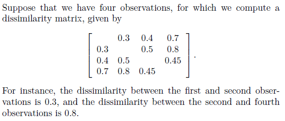

```r
# I'll recreate the matrix in the task as R object
Matrix <- matrix(c(0, 0.3, 0.4, 0.7,
                   0.3, 0, 0.5, 0.8,
                   0.4, 0.5, 0, 0.45,
                   0.7, 0.8, 0.45, 0), nrow = 4, byrow = TRUE)

d <- as.dist(Matrix)
```

# a)

On the basis of this dissimilarity matrix, sketch the dendrogram that results from hierarchically clustering these four observations using complete linkage. Be sure to indicate on the plot the height at which each fusion occurs, as well as the observations corresponding to each leaf in the dendrogram.

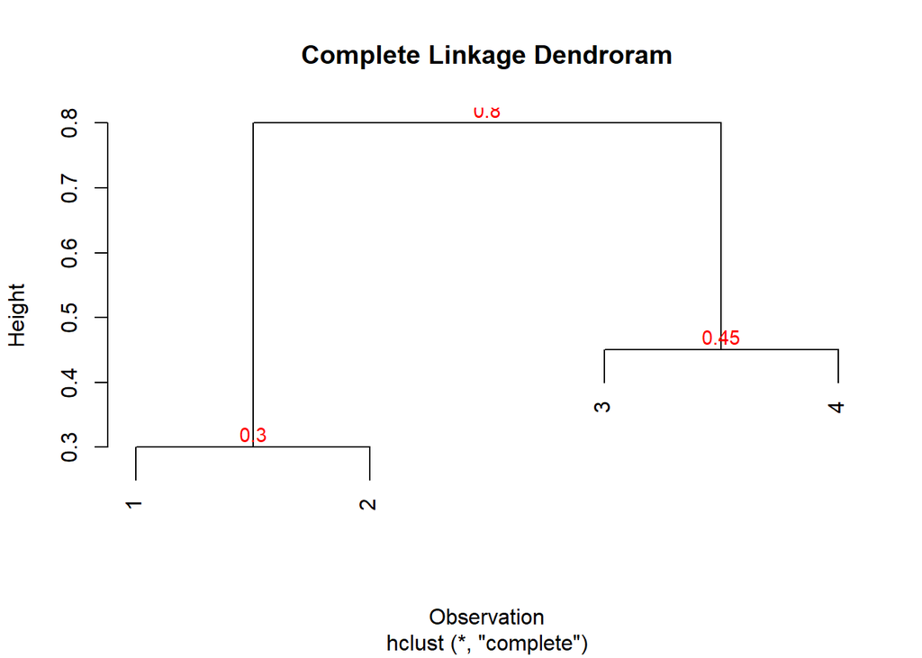

```r
# Using complete linkage and plotting the results
hc_linked_comp <- hclust(d, method = "complete")
plot(hc_linked_comp, main = "Complete Linkage Dendroram",
     xlab= "Observation", ylab = "Height")
# Also, adding the heights to the plot
heights <- hc_linked_comp$height
text(x = 1.5, y = heights[1] + 0.02, labels = heights[1], col = "red", cex = 0.9)
text(x = 3.5, y = heights[2] + 0.02, labels = heights[2], col = "red", cex = 0.9)
text(x = 2.5, y = heights[3] + 0.02, labels = heights[3], col = "red", cex = 0.9)
```

From this data we see three fusion points, each at different heights. Observations 1 and 2 being most similar at the point of fusion.

# b)

Repeat (a), this time using single linkage clustering.

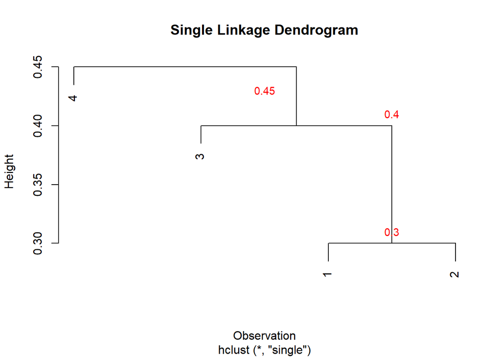

```r
# Using singe linkage method
hc_linked_single <- hclust(d, method = "single")
plot(hc_linked_single, main = "Single Linkage Dendrogram",
     xlab = "Observation", ylab = "Height")
# Again, adding heights
heights_single <- hc_linked_single$height
text(x = 3.5, y = heights_single[1] + 0.01, labels = heights_single[1], col = "red", cex = 0.9)
text(x = 3.5, y = heights_single[2] + 0.01, labels = heights_single[2], col = "red", cex = 0.9)
text(x = 2.5, y = heights_single[3] - 0.02, labels = heights_single[3], col = "red", cex = 0.9)
```

Using single linkage method seems to have reduced dissimilarities between groups at fusion points. Here, highest linkage point is 0.45 as opposed to 0.8 in part (a).

# c)

Suppose that we cut the dendrogram obtained in (a) such that two clusters result. Which observations are in each cluster?

Observing the dendrogram above in (a), if we cut it into two parts, the first cluster will have observations 1 and 2, and the second cluster has observations 3 and 4.

# d)

Suppose that we cut the dendrogram obtained in (b) such that two clusters result. Which observations are in each cluster?

Cutting the dendogram obtained in part (b), the clusters will look different. Cutting at the top height we will have two unequal clusters. The first cluster would have one observation: 4. And the second cluster would have observations 1, 2 and 3.

# e)

It is mentioned in this chapter that at each fusion in the dendrogram, the position of the two clusters being fused can be swapped without changing the meaning of the dendrogram. Draw a dendrogram that is equivalent to the dendrogram in (a), for which two or more of the leaves are repositioned, but for which the meaning of the dendrogram is the same.

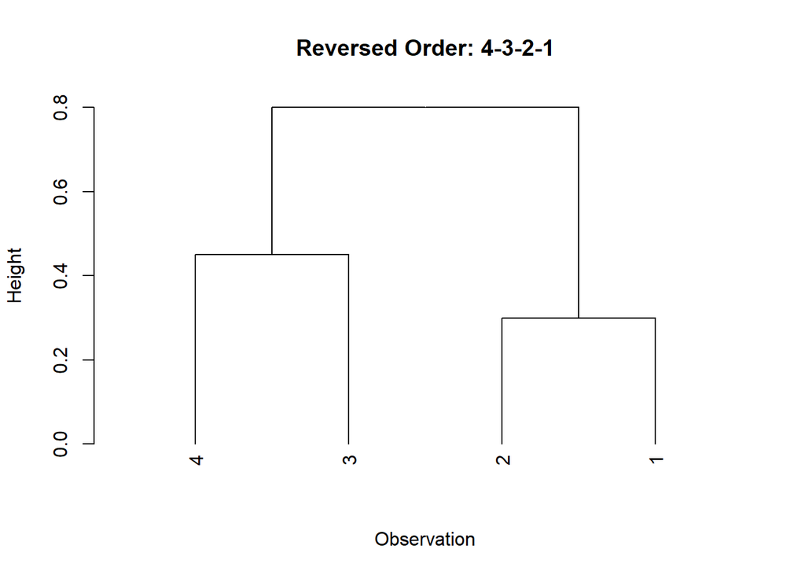

```r
dend <- as.dendrogram(hc_linked_comp)
dend_rev <- reorder(dend, c(4,3,2,1))
plot(dend_rev, main = "Reversed Order: 4-3-2-1",
     xlab = "Observation", ylab = "Height")
```

Just looking at this, it is a reversed of the original, however, the heights of fusion points remains the same for the same observations, so, it still has the same meaning as the original dedrogram.

## Task 8.8

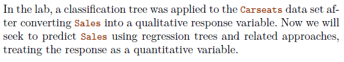

# a)

Split the data set into a training set and a test set.

```r
attach(Carseats)

# Assigning training set indexes
train_ind <- sample(1:nrow(Carseats), nrow(Carseats)*0.8)

# Separating the data into training set and test set
train_set <- Carseats[train_ind,]
test_set <- Carseats[-train_ind,]
```

# b)

Fit a regression tree to the training set. Plot the tree, and interpret the results. What test MSE do you obtain?

```r
r1_tree <- tree(Sales ~ ., data = train_set)
summary(r1_tree)
```

```
##
## Regression tree:
## tree(formula = Sales ~ ., data = train_set)
## Variables actually used in tree construction:
## [1] "ShelveLoc"   "Price"       "Age"         "Advertising" "CompPrice"
## Number of terminal nodes:  19
## Residual mean deviance:  2.485 = 748 / 301
## Distribution of residuals:
##     Min.  1st Qu.   Median     Mean  3rd Qu.     Max.
## -3.73500 -1.04900 -0.05558  0.00000  1.00100  4.30500
```

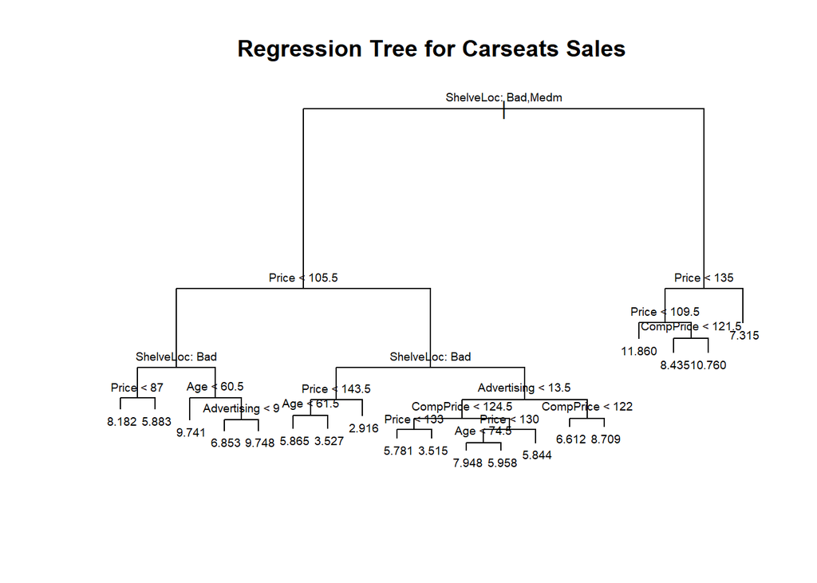

```r
par(mfrow = c(1, 1))
plot(r1_tree)
text(r1_tree, pretty = 4, cex = 0.6)
title("Regression Tree for Carseats Sales")
```

The tree does not look efficient enough as Shelve locations and price turn up more than once in the tree meaning that we have to consider the same variable more than once.

To obtain test MSE, I first predict using the test set and then use that to compute the error:

```r
r1_pred <- predict(r1_tree, newdata = test_set)
r1_test_mse <- mean((r1_pred - test_set$Sales)^2)
table(r1_test_mse)
```

```
## r1_test_mse
## 4.54903911983318
##                1
```

Above is the test MSE I obtained. It does not seem too high, but it is also not a very low one. Without context of other methods and their results, it is difficult to judge if we can do better.

# c)

Use cross-validation in order to determine the optimal level of tree complexity. Does pruning the tree improve the test MSE?

I first run cross-validation and then I plot it.

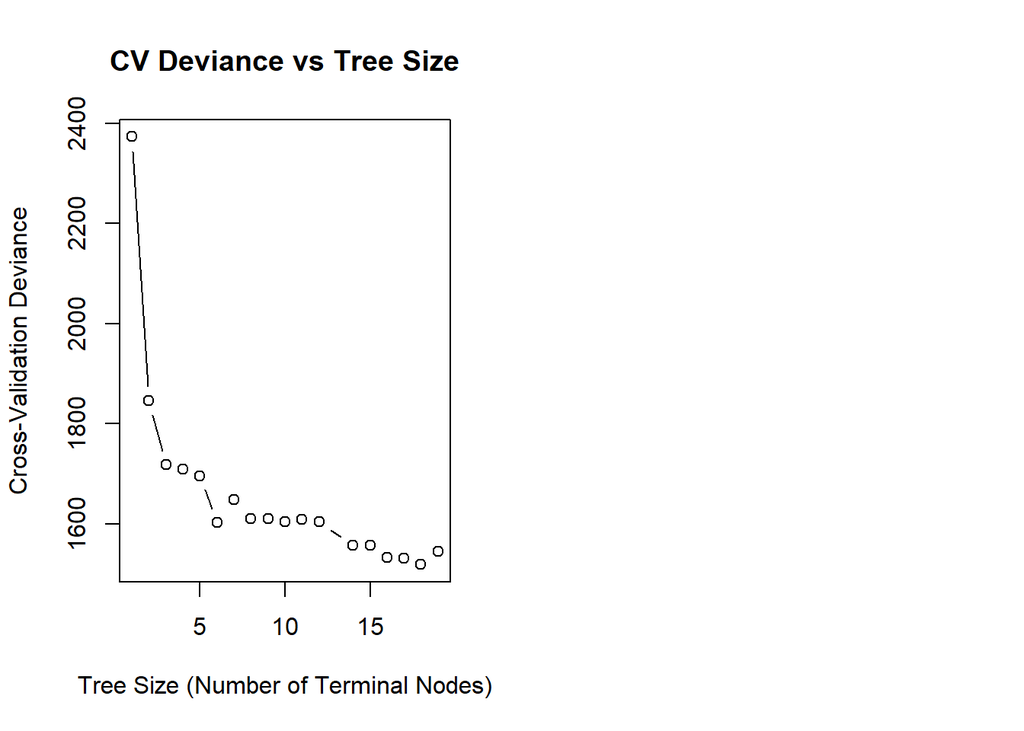

```r
# CV
cv_tree <- cv.tree(r1_tree)

# Plotting
par(mfrow = c(1, 2))
plot(cv_tree$size, cv_tree$dev, type = "b",
     xlab = "Tree Size (Number of Terminal Nodes)",
     ylab = "Cross-Validation Deviance",
     main = "CV Deviance vs Tree Size")
```

Looking at he graph it does not immediately jump out at me, that we should somehow agressively prune the tree. It seems that the full tree is rather close to being optimal. However, I will now check what is the optimal level of tree complexity and what is the MSE of the pruned tree.

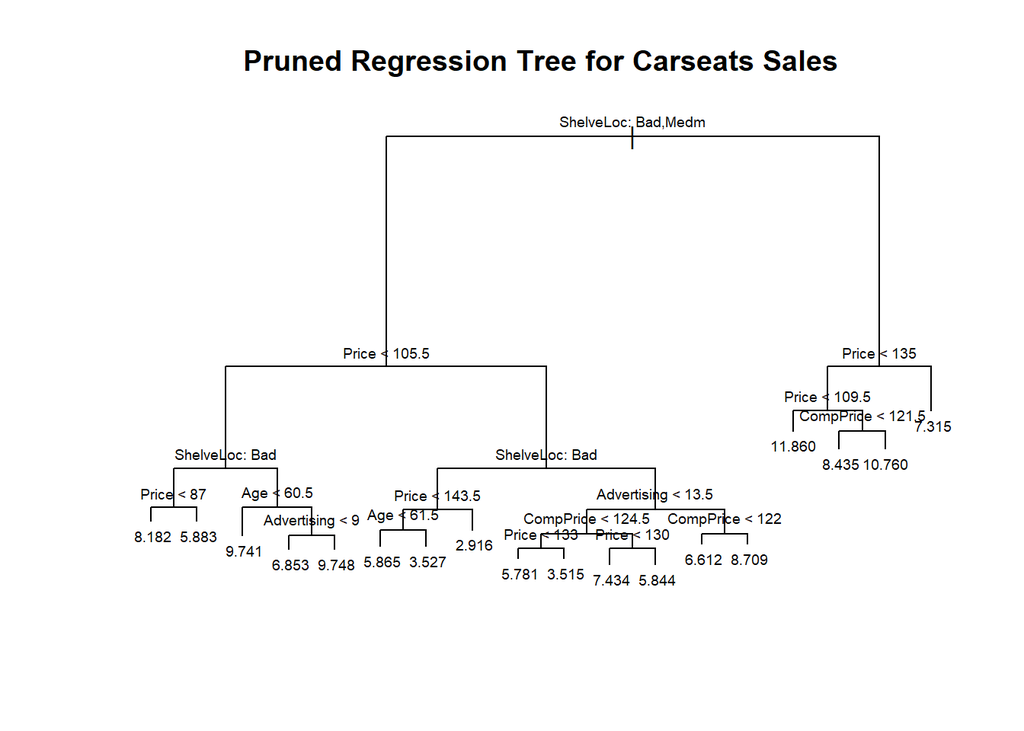

```r
# Finding the optimal tree size
optimal_tree_size <- cv_tree$size[which.min(cv_tree$dev)]

# Pruning the tree
pruned_tree <- prune.tree(r1_tree, best = optimal_tree_size)

# Ploting the pruned tree
par(mfrow = c(1, 1))
plot(pruned_tree)
text(pruned_tree, pretty = 4, cex = 0.6)
title("Pruned Regression Tree for Carseats Sales")
```

This new tree removes one branch from the previous tree.

```r
# Re-predicting with Pruned tree model
pruned_pred <- predict(pruned_tree, newdata = test_set)
# Calculating MSE
pruned_mse <- mean((pruned_pred-test_set$Sales)^2)
# Creating a table to compare the MSE results
results <- matrix(c(r1_test_mse, pruned_mse), ncol = 1)
rownames(results) <- c("Unpruned Tree", "Pruned Tree")
colnames(results) <- "Test MSE"
print(results)
```

```
##               Test MSE
## Unpruned Tree 4.549039
## Pruned Tree   4.611444
```

This result actually shows that the pruned tree performs worse than the full tree. Therefore, I would conclude the unpruned tree is better for prediction than the pruned tree.

# d)

Use the bagging approach in order to analyze this data. What test MSE do you obtain? Use the feature_importance_ values to determine which variables are most important.

```r
# Estimating the model
bagging_model <- randomForest(Sales ~ ., data = train_set, mtry = 10, importance = TRUE)
# Predicting and calculating the MSE
bagging_pred <- predict(bagging_model, newdata = test_set)
bagging_mse <- mean((bagging_pred-test_set$Sales)^2)
bagging_mse
```

```
## [1] 2.553049
```

Immediately it is obvious, that bagging method gives way more accurate predictions that either of the tree models. MSE being 2.55 is a clear improvement over MSE’s of the tree models of over 4.

```r
# Extracting variable importance
bagging_importance <- importance(bagging_model)
bagging_importance
```

```
##               %IncMSE IncNodePurity
## CompPrice   30.935917    240.422094
## Income       7.665395    123.241063
## Advertising 23.107077    170.368700
## Population   2.023060     83.122227
## Price       70.987918    710.239241
## ShelveLoc   76.246061    670.056229
## Age         21.016268    203.836936
## Education    3.012073     65.165506
## Urban       -1.845697      8.880231
## US           2.906447     11.856564
```

There are two variables that are clearly most important for predicting sales: Shelve Location and Price. A lot less important, but not minor things are: Competition price, Advertising and Age, but other things do not seem to matter all that much.

# e)

Use random forests to analyze this data. What test MSE do you obtain? Use the feature_importance_ values to determine which variables are most important. Describe the effect of m, the number of variables considered at each split, on the error rate obtained.

```r
# Preparing to rerun the model several times
mtry_values <- c(1, 2, 3, 4, 5, 6, 7, 8, 9)
results_rf_df <-data.frame(mtry = mtry_values, Test_MSE = NA)

#Running the loop
for (i in 1:length(mtry_values)){
  m <- mtry_values[i]
  # The model
  rf_model <- randomForest(Sales ~ ., data = train_set, mtry = m, importance = TRUE)

  # Calculating MSE
  rf_pred <- predict(rf_model, newdata = test_set)
  rf_mse <- mean((rf_pred-test_set$Sales)^2)

  # Storing
  results_rf_df[i, "Test_MSE"] <- rf_mse
}
results_rf_df
```

```
##   mtry Test_MSE
## 1    1 5.901635
## 2    2 4.023571
## 3    3 3.373115
## 4    4 2.997255
## 5    5 2.699431
## 6    6 2.649529
## 7    7 2.565958
## 8    8 2.536534
## 9    9 2.552180
```

The results above show that the improvement to the MSE is not linear with inclusion of more variables at each split. It improves until the 8th variables and then starts to increase again. I don’t include the m = 10 version because I already have this MSE because it was the bagging approach.

```r
# I will rerun the model with standard choise for random forest models of m = sqrt(p), which for us it around 3
rf_model <- randomForest(Sales ~ ., data = train_set, mtry = 3, importance = TRUE)
# Extracting importance
rf_importance <- importance(rf_model)
rf_importance
```

```
##                  %IncMSE IncNodePurity
## CompPrice   14.919558981     215.06991
## Income       1.848736630     167.19032
## Advertising 15.481702959     194.65421
## Population  -0.004862335     148.92331
## Price       44.948252421     565.91648
## ShelveLoc   50.807971614     540.09662
## Age         16.392583194     239.52325
## Education   -0.172639710     105.55826
## Urban       -1.930920981      19.27966
## US           4.154394330      28.04656
```

Similarly as in bagging approach, the the most important variables are shelving locations and prices. Somewhat important are competition price, advertising and age. Other variables are not important in this model.

# f)

Now analyze the data using BART, and report your results.

```r
# Preparing data for the model
x_train <- model.matrix(Sales ~ ., data = train_set)[,-1]
y_train <- train_set$Sales
x_test <- model.matrix(Sales ~ ., data = test_set)[,-1]
y_test <- test_set$Sales

# Running the model
bart_model <- BART::gbart(x.train = x_train, y.train = y_train, x.test = x_test)
```

```
## *****Calling gbart: type=1
## *****Data:
## data:n,p,np: 320, 11, 80
## y1,yn: 1.282469, 2.562469
## x1,x[n*p]: 142.000000, 1.000000
## xp1,xp[np*p]: 141.000000, 1.000000
## *****Number of Trees: 200
## *****Number of Cut Points: 69 ... 1
## *****burn,nd,thin: 100,1000,1
## *****Prior:beta,alpha,tau,nu,lambda,offset: 2,0.95,0.273474,3,0.210384,7.38753
## *****sigma: 1.039253
## *****w (weights): 1.000000 ... 1.000000
## *****Dirichlet:sparse,theta,omega,a,b,rho,augment: 0,0,1,0.5,1,11,0
## *****printevery: 100
##
## MCMC
## done 0 (out of 1100)
## done 100 (out of 1100)
## done 200 (out of 1100)
## done 300 (out of 1100)
## done 400 (out of 1100)
## done 500 (out of 1100)
## done 600 (out of 1100)
## done 700 (out of 1100)
## done 800 (out of 1100)
## done 900 (out of 1100)
## done 1000 (out of 1100)
## time: 4s
## trcnt,tecnt: 1000,1000
```

```r
# Computing the MSE
bart_MSE <- mean((y_test - bart_model$yhat.test.mean)^2)
bart_MSE
```

```
## [1] 1.285016
```

The MSE (1.285) from this method is lowest of all used in the exercise, which to me suggests that it is best able to predict Sales.

## Task 11.11

# a)

Create two groups of observations. In Group 1, X < 2, whereas in Group 2, X >= 2. Plot the Kaplan-Meier survival curves corresponding to the two groups. Be sure to label the curves so that it is clear which curve corresponds to which group. By eye, does there appear to be a difference between the two groups’ survival curves?

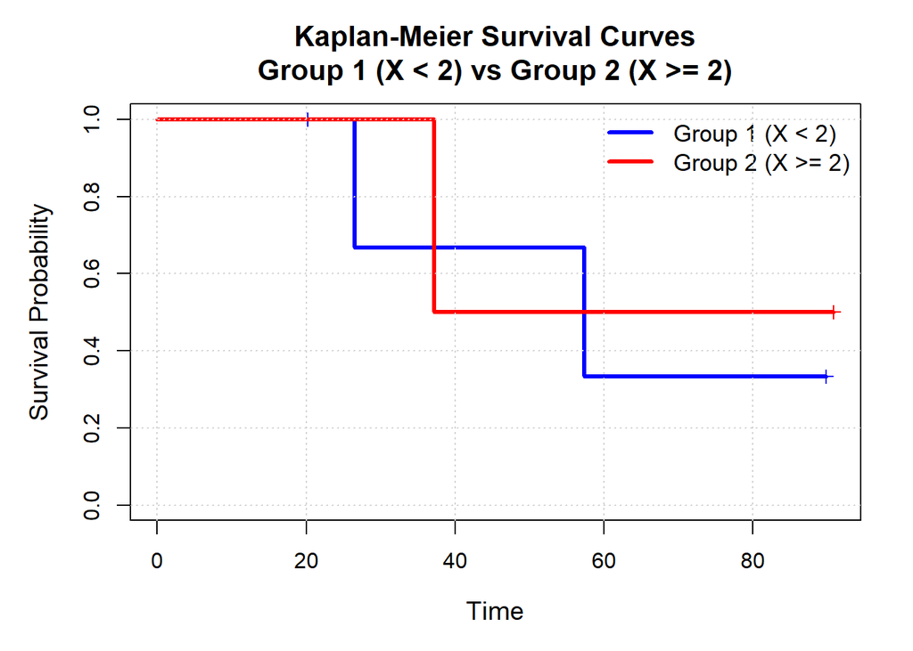

```r
# I could not find a dataset that might be used here, so I am constructing it from the table itself
y <- c(26.5,37.2,57.3,90.8,20.2,89.8)
delta <- c(1,1,1,0,0,0)
x <- c(0.1,11,-0.3,2.8,1.8,0.4)

# Creating a data frame
df_cox <- data.frame(
  Time = y,
  Censoring_ind = delta,
  Covariate = x
)

# Creating groups
df_cox$group <- ifelse(df_cox$Covariate < 2, "Group 1 (X < 2)", "Group 2 (X >= 2)")

# Fitting the Kaplan-Meier
km_m1 <- survfit(Surv(Time, Censoring_ind) ~ group, data = df_cox)

# Plotting the results
par(mfrow = c(1, 1), mar = c(5, 5, 4, 2))
plot(km_m1,
     xlab = "Time",
     ylab = "Survival Probability",
     main = "Kaplan-Meier Survival Curves\nGroup 1 (X < 2) vs Group 2 (X >= 2)",
     col = c("blue", "red"),
     lwd = 3,
     mark.time = TRUE,
     cex.lab = 1.2,
     cex.main = 1.3)

legend("topright",
       legend = c("Group 1 (X < 2)", "Group 2 (X >= 2)"),
       col = c("blue", "red"),
       lwd = 3,
       bty = "n",
       cex = 1.1)
grid()
```

# b)

Fit Cox’s proportional hazards model, using the group indicator as a covariate. What is the estimated coefficient? Write a sentence providing the interpretation of this coefficient, in terms of the hazard or the instantaneous probability of the event. Is there evidence that the true coefficient value is non-zero?

```r
# Creating a binary group indicator
df_cox$indicator <- ifelse(df_cox$Covariate >= 2, 1, 0)

# Fitting the model
cox_m1 <- coxph(Surv(Time, Censoring_ind) ~ indicator, data = df_cox)
summary(cox_m1)
```

```
## Call:
## coxph(formula = Surv(Time, Censoring_ind) ~ indicator, data = df_cox)
##
##   n= 6, number of events= 3
##
##              coef exp(coef) se(coef)      z Pr(>|z|)
## indicator -0.3401    0.7117   1.2359 -0.275    0.783
##
##           exp(coef) exp(-coef) lower .95 upper .95
## indicator    0.7117      1.405   0.06314     8.022
##
## Concordance= 0.556  (se = 0.169 )
## Likelihood ratio test= 0.08  on 1 df,   p=0.8
## Wald test            = 0.08  on 1 df,   p=0.8
## Score (logrank) test = 0.08  on 1 df,   p=0.8
```

The estimated coefficient is -0.3401, and the exponent of it (or so called hazard) is 0.71, which means, that if you are in group 2, you have only 71% the risk of instantaneous event happening. However, the p-value is as high as 0.783, meaning that the result lacks statistical significance.

# c)

Recall from Section 11.5.2 that in the case of a single binary covariate, the log-rank test statistic should be identical to the score statistic for the Cox model. Conduct a log-rank test to determine whether there is a difference between the survival curves for the two groups. How does the p-value for the log-rank test statistic compare to the p-value for the score statistic for the Cox model from (b)?

```r
# Log rank test
logrank <- survdiff(Surv(Time, Censoring_ind) ~ indicator, data = df_cox)
logrank_pvalue <- 1 - pchisq(logrank$chisq, df = 1)
logrank_pvalue
```

```
## [1] 0.7821768
```

The Cox model p-value was 0.783 and log rank test p-value is 0.7821768, which, although not identical, I would say, is enough to conclude, that the results from both are in effect identical. The difference might be due to rounding, or some other minor detail. In fact, the Cox model summary gives a rounded logrank test 0.8, so, if we did the same “trick” we would have identical results.